# Estadística Fundamental para Ciencias de la Salud

Variables Aleatorias y Distribuciones de Probabilidad

Giovany Babativa-Márquez, PhD

jgbabativam@unal.edu.co

# VARIABLES ALEATORIAS

## ¿Qué es una Variable Aleatoria?

### Definición formal

Una **variable aleatoria** $X$ es una función que asigna un valor numérico a cada resultado de un experimento aleatorio:

$$X : \Omega \longrightarrow \mathbb{R}$$

**Tip**

Cuando realizamos un examen clínico, el resultado es incierto antes de hacerlo. La **variable aleatoria** es el mecanismo que convierte ese resultado en un número con el que podemos operar matemáticamente.

### Ejemplos en Ciencias de la Salud

| Experimento | Variable aleatoria $X$ | Valores posibles |
| --- | --- | --- |
| Tomar la presión arterial | Presión sistólica (mmHg) | $[0, +\infty)$ |
| Revisar una sala de urgencias | Número de pacientes | $0, 1, 2, \ldots$ |
| Aplicar un tratamiento | Tiempo de recuperación (días) | $(0, +\infty)$ |
| Realizar prueba diagnóstica | Resultado (positivo/negativo) | $\{0, 1\}$ |
| Controlar UCI en un turno | Camas ocupadas | $0, 1, \ldots, n$ |

## Tipos de Variables Aleatorias

### Discreta

Toma valores **contables** (finitos o infinito numerable):

$$X \in \{x_1, x_2, x_3, \ldots\}$$

**Ejemplos clínicos:**

- Número de pacientes con fiebre en una sala
- Número de medicamentos administrados
- Conteo de eventos adversos por turno

### Continua

Toma valores en un **intervalo** de $\mathbb{R}$ (infinito no numerable):

$$X \in (a, b) \subseteq \mathbb{R}$$

**Ejemplos clínicos:**

- Presión arterial (mmHg)
- Temperatura corporal (°C)
- Peso del paciente (kg)
- Tiempo hasta el alta (horas)

## Función de Distribución Acumulada (FDA)

### Definición

Para cualquier variable aleatoria $X$ (discreta o continua), la **función de distribución acumulada** es:

$$\boxed{F(x) = P(X \leq x), \quad x \in \mathbb{R}}$$

### Propiedades

- $0 \leq F(x) \leq 1$ para todo $x$
- $F$ es **no decreciente**: si $a < b$ entonces $F(a) \leq F(b)$
- $\displaystyle\lim_{x \to -\infty} F(x) = 0$ y $\displaystyle\lim_{x \to +\infty} F(x) = 1$
- $P(a < X \leq b) = F(b) - F(a)$

# VARIABLES DISCRETAS

## Función de Probabilidad Puntual (FPP)

### Definición

Para una variable aleatoria discreta $X$, la **función de probabilidad puntual** se define como:

$$\boxed{p(x) = P(X = x)}$$

### Propiedades

1. $p(x) \geq 0$, $\forall x$
2. $\displaystyle\sum_{x} p(x) = 1$
3. $P(X \in A) = \displaystyle\sum_{x \in A} p(x)$

## Ejemplo: Eventos adversos por turno

En una unidad de hospitalización se registra el número de **eventos adversos leves** $X$ durante un turno de 8 horas:

| $x$ | 0 | 1 | 2 | 3 | 4 |
| --- | --- | --- | --- | --- | --- |
| $p(x)$ | 0.30 | 0.35 | 0.20 | 0.10 | 0.05 |

**Verificación:**

$$\sum p(x) = 0.30 + 0.35 + 0.20 + 0.10 + 0.05 = 1 \checkmark$$

### Cálculo de probabilidades

Con la distribución de eventos adversos:

$$P(X \geq 2) = p(2) + p(3) + p(4) = 0.20 + 0.10 + 0.05 = \mathbf{0.35}$$

$$P(1 \leq X \leq 3) = p(1) + p(2) + p(3) = 0.35 + 0.20 + 0.10 = \mathbf{0.65}$$

$$P(X < 2) = p(0) + p(1) = 0.30 + 0.35 = \mathbf{0.65}$$

## Representación gráfica de la FPP

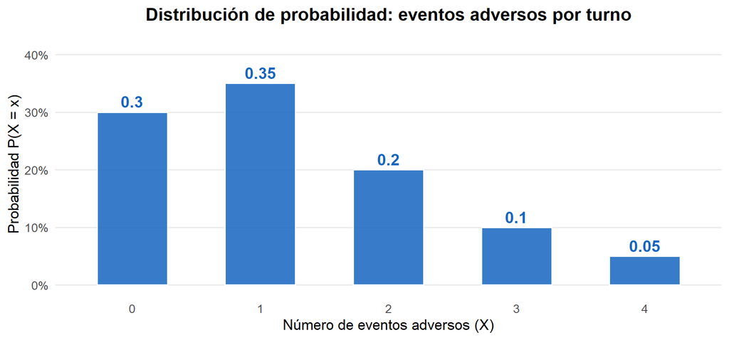

# VARIABLES CONTINUAS

## Función de Densidad de Probabilidad (FDP)

### Definición

Para una variable aleatoria continua $X$, la **función de densidad de probabilidad** $f(x)$ satisface:

$$\boxed{P(a \leq X \leq b) = \int_a^b f(x)\, dx}$$

### Propiedades

1. $f(x) \geq 0$ para todo $x$
2. $\displaystyle\int_{-\infty}^{+\infty} f(x)\, dx = 1$
3. **Importante:** $P(X = x) = 0$ para cualquier valor puntual
4. $P(a < X < b) = P(a \leq X \leq b) = F(b) - F(a)$

## Interpretación gráfica

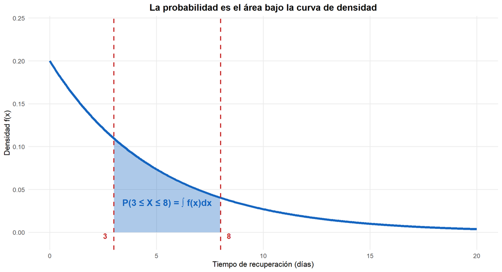

## Ejemplo: Tiempo de recuperación post-cirugía

El tiempo de recuperación $X$ (en días) tras una cirugía de rodilla sigue una distribución con densidad:

$$f(x) = \frac{1}{5} e^{-x/5}, \quad x > 0$$

**¿Cuál es la probabilidad de recuperarse en menos de 3 días?**

$$P(X < 3) = \int_0^3 \frac{1}{5} e^{-x/5}\, dx = 1 - e^{-3/5} \approx 0.451$$

**¿Y entre 5 y 10 días?**

$$P(5 < X < 10) = e^{-1} - e^{-2} \approx 0.368 - 0.135 = 0.233$$

# VALOR ESPERADO

## Definición: Valor Esperado

El **valor esperado** (o media) de una variable aleatoria $X$ mide su valor promedio en el largo plazo.

### Variable discreta

$$\boxed{E[X] = \sum_{x} x \cdot p(x)}$$

### Variable continua

$$\boxed{E[X] = \int_{-\infty}^{+\infty} x \cdot f(x)\, dx}$$

> **Interpretación clínica:** Si observamos el mismo proceso clínico muchas veces, $E[X]$ es el promedio de los resultados que obtendríamos.

## Ejemplo: Eventos adversos

Retomando la distribución de eventos adversos por turno:

| $x$ | 0 | 1 | 2 | 3 | 4 |
| --- | --- | --- | --- | --- | --- |
| $p(x)$ | 0.30 | 0.35 | 0.20 | 0.10 | 0.05 |

$$E[X] = 0(0.30) + 1(0.35) + 2(0.20) + 3(0.10) + 4(0.05)$$

$$E[X] = 0 + 0.35 + 0.40 + 0.30 + 0.20 = \mathbf{1.25}$$

**Interpretación:** En promedio se producen **1.25 eventos adversos leves** por turno de 8 horas en esta unidad.

## Propiedades del Valor Esperado

Sea $X$, $Y$ variables aleatorias y $a$, $b$ constantes:

1. $E[a] = a$
2. $E[aX] = a \cdot E[X]$
3. $E[X + b] = E[X] + b$
4. **Linealidad:** $E[aX + b] = a \cdot E[X] + b$
5. **Aditividad:** $E[X + Y] = E[X] + E[Y]$ (siempre)
6. Si $X$ e $Y$ son independientes: $E[XY] = E[X] \cdot E[Y]$

### Aplicación clínica: Transformación de escala

La **frecuencia cardíaca** de un paciente en reposo tiene $E[FC] = 72$ lpm.

Si medimos en otra unidad: $FC^* = 0.5 \cdot FC + 10$ (escala relativa):

$$E[FC^*] = 0.5 \cdot E[FC] + 10 = 0.5 \cdot 72 + 10 = \mathbf{46}$$

Si registramos la **suma** de frecuencias cardíacas de 3 pacientes:

$$E[FC_1 + FC_2 + FC_3] = E[FC_1] + E[FC_2] + E[FC_3] = 72 + 72 + 72 = \mathbf{216}$$

# VARIANZA Y DESVIACIÓN ESTÁNDAR

## Definición: Varianza

La **varianza** mide la dispersión de $X$ alrededor de su media $\mu = E[X]$:

$$\boxed{Var(X) = E\left[(X - \mu)^2\right]}$$

### Fórmula de cálculo (equivalente y más práctica)

$$\boxed{Var(X) = E[X^2] - (E[X])^2}$$

### Desviación estándar

$$\sigma_X = \sqrt{Var(X)}$$

La desviación estándar tiene las **mismas unidades** que $X$, lo que facilita su interpretación clínica.

## Ejemplo: Varianza de eventos adversos

| $x$ | $p(x)$ | $x^2$ | $x^2 \cdot p(x)$ |
| --- | --- | --- | --- |
| 0 | 0.30 | 0 | 0.000 |
| 1 | 0.35 | 1 | 0.350 |
| 2 | 0.20 | 4 | 0.800 |
| 3 | 0.10 | 9 | 0.900 |
| 4 | 0.05 | 16 | 0.800 |

$$E[X^2] = 2.850 \quad \Rightarrow \quad Var(X) = 2.850 - (1.25)^2 = 2.850 - 1.5625 = \mathbf{1.2875}$$

$$\sigma_X = \sqrt{1.2875} \approx \mathbf{1.13} \text{ eventos adversos}$$

## Propiedades de la Varianza

Sean $X$, $Y$ variables aleatorias, $a$, $b$ constantes:

1. $Var(b) = 0$
2. $Var(X + b) = Var(X)$
3. $Var(aX) = a^2 \cdot Var(X)$
4. **Lineal:** $Var(aX + b) = a^2 \cdot Var(X)$
5. Si $X$ e $Y$ son **independientes**:
   $$Var(X + Y) = Var(X) + Var(Y)$$

> **Nota:** En general, $Var(X + Y) = Var(X) + Var(Y) + 2\,Cov(X,Y)$

# COVARIANZA Y CORRELACIÓN

## Definición: Covarianza

La **covarianza** mide la relación lineal entre dos variables aleatorias $X$ e $Y$:

$$\boxed{Cov(X,Y) = E\left[(X - \mu_X)(Y - \mu_Y)\right] = E[XY] - E[X]\cdot E[Y]}$$

| Valor de $Cov(X,Y)$ | Interpretación |
| --- | --- |
| $> 0$ | Cuando $X$ aumenta, $Y$ tiende a **aumentar** |
| $< 0$ | Cuando $X$ aumenta, $Y$ tiende a **disminuir** |
| $= 0$ | No hay relación lineal (puede haber relación no lineal) |

## Correlación de Pearson

La covarianza depende de las unidades. El **coeficiente de correlación** estandariza:

$$\boxed{\rho_{XY} = \frac{Cov(X,Y)}{\sigma_X \cdot \sigma_Y}, \quad -1 \leq \rho \leq 1}$$

| $\rho$ | Interpretación |
| --- | --- |
| $\approx 1$ | Relación lineal positiva fuerte |
| $\approx -1$ | Relación lineal negativa fuerte |
| $\approx 0$ | Sin relación lineal |

## Ejemplo clínico: IMC y Presión Arterial

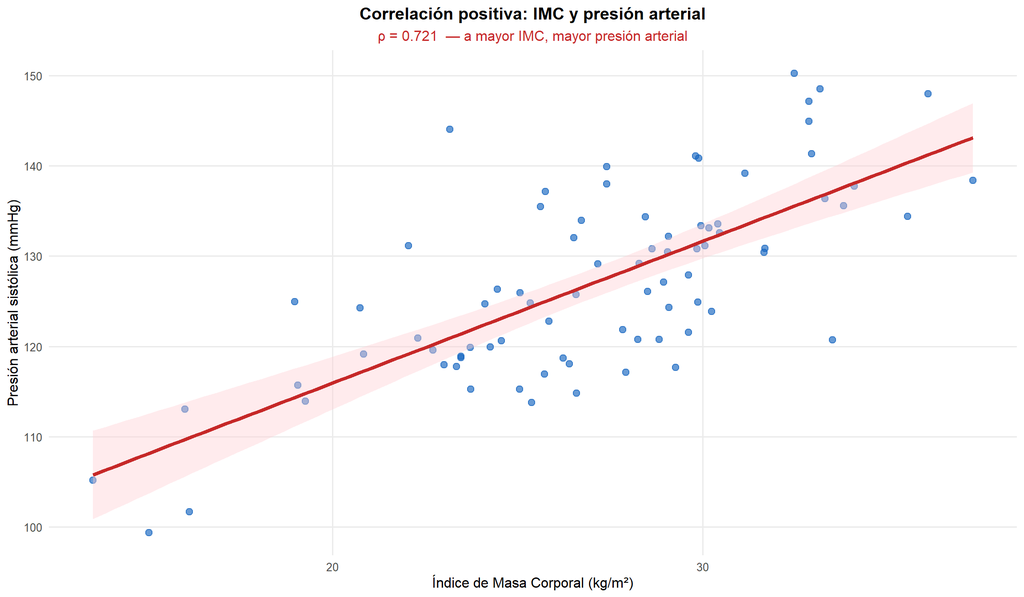

# DISTRIBUCIONES DISCRETAS

## Distribución Bernoulli

### Definición

Una variable aleatoria $X$ sigue una distribución **Bernoulli** con parámetro $p$ si el experimento tiene exactamente **dos resultados posibles**: éxito ($X=1$) o fracaso ($X=0$):

$$X \sim \text{Ber}(p)$$

### Función de probabilidad

$$p(x) = p^x (1-p)^{1-x}, \quad x \in \{0, 1\}$$

|  | Fracaso ($X=0$) | Éxito ($X=1$) |
| --- | --- | --- |
| $p(x)$ | $1-p$ | $p$ |

### Parámetros

$$E[X] = p \qquad Var(X) = p(1-p)$$

### Ejemplos en Ciencias de la Salud

- Un paciente **responde** ($X=1$) o **no responde** ($X=0$) a un antibiótico, con $p = 0.80$
- Un recién nacido presenta un **APGAR bajo** ($X=1$), con $p = 0.05$
- Una prueba diagnóstica resulta **positiva** ($X=1$), con $p$ igual a la sensibilidad
- Un paciente **desarrolla úlcera de presión** ($X=1$) en su estancia, con $p = 0.12$

## Código R: Distribución Bernoulli

En R, la Bernoulli es un caso especial de la Binomial con `size = 1`:

```r
# P(X = 1): paciente responde al antibiótico, p = 0.80
dbinom(x = 1, size = 1, prob = 0.80)
```

```
[1] 0.8
```

```r
# P(X = 0): paciente NO responde
dbinom(x = 0, size = 1, prob = 0.80)
```

```
[1] 0.2
```

```r
# Valor esperado y varianza (p = 0.80)
p <- 0.80
cat("E[X] =", p, "\nVar(X) =", p * (1 - p))
```

```
E[X] = 0.8
Var(X) = 0.16
```

## Distribución Binomial

### Definición

Si se realizan $n$ ensayos de Bernoulli **independientes**, cada uno con probabilidad de éxito $p$, la variable aleatoria $X$ = número de éxitos sigue una distribución **Binomial**:

$$X \sim \text{Bin}(n, p)$$

### Función de probabilidad

$$\boxed{p(x) = \binom{n}{x} p^x (1-p)^{n-x}, \quad x = 0, 1, 2, \ldots, n}$$

### Parámetros

$$\boxed{E[X] = np \qquad Var(X) = np(1-p)}$$

### Condiciones de aplicación

- $n$ ensayos **fijos** e independientes
- Cada ensayo tiene solo dos resultados (éxito / fracaso)
- La probabilidad de éxito $p$ es **constante** en cada ensayo

### Ejemplo clínico

De **15 pacientes** con neumonía bacteriana tratados con un antibiótico específico, cada uno tiene probabilidad de responder de $p = 0.75$, independientemente de los demás. Sea $X$ el número de pacientes que responden.

$$X \sim \text{Bin}(15,\; 0.75)$$

### Cálculo manual

$$P(X = 12) = \binom{15}{12}(0.75)^{12}(0.25)^3 = 455 \cdot (0.75)^{12} \cdot (0.25)^3 \approx 0.225$$

$$E[X] = 15 \times 0.75 = 11.25 \text{ pacientes}$$

$$\sigma_X = \sqrt{15 \times 0.75 \times 0.25} = \sqrt{2.8125} \approx 1.68 \text{ pacientes}$$

## Código R: Distribución Binomial

```r
# X ~ Bin(15, 0.75): respuesta al antibiótico
# P(X = 12): exactamente 12 pacientes responden
dbinom(x = 12, size = 15, prob = 0.75)
```

```
[1] 0.2251991
```

```r
# P(X <= 10): a lo sumo 10 responden
pbinom(q = 10, size = 15, prob = 0.75)
```

```
[1] 0.3135141
```

```r
# P(X >= 13): al menos 13 responden
1 - pbinom(q = 12, size = 15, prob = 0.75)
```

```
[1] 0.2360878
```

```r
# Percentil 90 (mínimo k tal que P(X <= k) >= 0.90)
qbinom(p = 0.90, size = 15, prob = 0.75)
```

```
[1] 13
```

## Visualización: Distribución Binomial

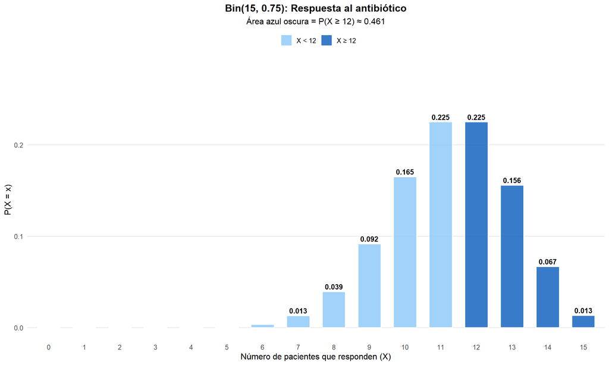

## Distribución Hipergeométrica

### Definición

Describe el número de éxitos al extraer $n$ elementos **sin reposición** de una población finita de $N$ elementos, de los cuales $K$ son del tipo de interés.

$$X \sim \text{Hiper}(N, K, n)$$

### Función de probabilidad

$$\boxed{p(x) = \frac{\binom{K}{x}\binom{N-K}{n-x}}{\binom{N}{n}}, \quad x = \max(0, n+K-N), \ldots, \min(n, K)}$$

### Parámetros

$$E[X] = n \cdot \frac{K}{N} \qquad Var(X) = n \cdot \frac{K}{N} \cdot \frac{N-K}{N} \cdot \frac{N-n}{N-1}$$

> El factor $\dfrac{N-n}{N-1}$ se llama **factor de corrección por población finita** y refleja que al no haber reposición, la varianza es menor que en la Binomial.

### Ejemplo clínico: Selección de pacientes para estudio

Una sala de rehabilitación tiene **20 pacientes**, de los cuales **8 tienen diagnóstico de diabetes**. Se seleccionan al azar **6 pacientes** para participar en un programa piloto.

Sea $X$ = número de pacientes diabéticos seleccionados.

$$X \sim \text{Hiper}(N=20,\; K=8,\; n=6)$$

$$P(X = 2) = \frac{\binom{8}{2}\binom{12}{4}}{\binom{20}{6}} = \frac{28 \times 495}{38760} \approx 0.357$$

$$E[X] = 6 \cdot \frac{8}{20} = 2.4 \quad \text{pacientes diabéticos esperados}$$

## Código R: Distribución Hipergeométrica

```r
# X ~ Hiper(N=20, K=8, n=6): pacientes diabéticos
# dhyper(x, m, n, k): m=éxitos, n=fracasos, k=extraídos

# P(X = 2): exactamente 2 diabéticos seleccionados
dhyper(x = 2, m = 8, n = 12, k = 6)
```

```
[1] 0.3575851
```

```r
# P(X <= 3): a lo sumo 3 diabéticos
phyper(q = 3, m = 8, n = 12, k = 6)
```

```
[1] 0.8627451
```

```r
# P(X >= 4): al menos 4 diabéticos
1 - phyper(q = 3, m = 8, n = 12, k = 6)
```

```
[1] 0.1372549
```

```r
# Valor esperado
6 * 8/20
```

```
[1] 2.4
```

## Distribución de Poisson

### Definición

Modela el número de **eventos raros o poco frecuentes** que ocurren en un intervalo de tiempo o espacio determinado, cuando los eventos ocurren a tasa constante e independientemente entre sí.

$$X \sim \text{Poisson}(\lambda)$$

### Función de probabilidad

$$\boxed{p(x) = \frac{e^{-\lambda}\, \lambda^x}{x!}, \quad x = 0, 1, 2, \ldots}$$

### Parámetros

$$\boxed{E[X] = \lambda \qquad Var(X) = \lambda}$$

> Una característica única: **media = varianza = $\lambda$**.

### Condiciones de aplicación en salud

- Número de **ingresos a urgencias** por hora
- Número de **infecciones nosocomiales** por semana
- Casos de una **enfermedad rara** en una población por año
- Número de **caídas de pacientes** en una unidad por mes
- Llamadas al **servicio de emergencias** por noche

### Ejemplo: Ingresos a urgencias

En un hospital, el promedio de pacientes que ingresan a urgencias es de **$\lambda = 4$ pacientes por hora**. Sea $X$ el número de ingresos en una hora.

$$X \sim \text{Poisson}(4)$$

$$P(X = 6) = \frac{e^{-4} \cdot 4^6}{6!} = \frac{0.0183 \times 4096}{720} \approx 0.104$$

$$P(X \leq 2) = \sum_{x=0}^{2} \frac{e^{-4} \cdot 4^x}{x!} = e^{-4}(1 + 4 + 8) = 0.238$$

## Código R: Distribución de Poisson

```r
# X ~ Poi(4): ingresos a urgencias por hora
# P(X = 6): exactamente 6 ingresos
dpois(x = 6, lambda = 4)
```

```
[1] 0.1041956
```

```r
# P(X <= 2): a lo sumo 2 ingresos (guardia tranquila)
ppois(q = 2, lambda = 4)
```

```
[1] 0.2381033
```

```r
# P(X >= 7): 7 o más ingresos (turno muy ocupado)
1 - ppois(q = 6, lambda = 4)
```

```
[1] 0.110674
```

```r
# Percentil 95: valor que no se supera el 95% del tiempo
qpois(p = 0.95, lambda = 4)
```

```
[1] 8
```

## Visualización: Comparación de distribuciones Poisson

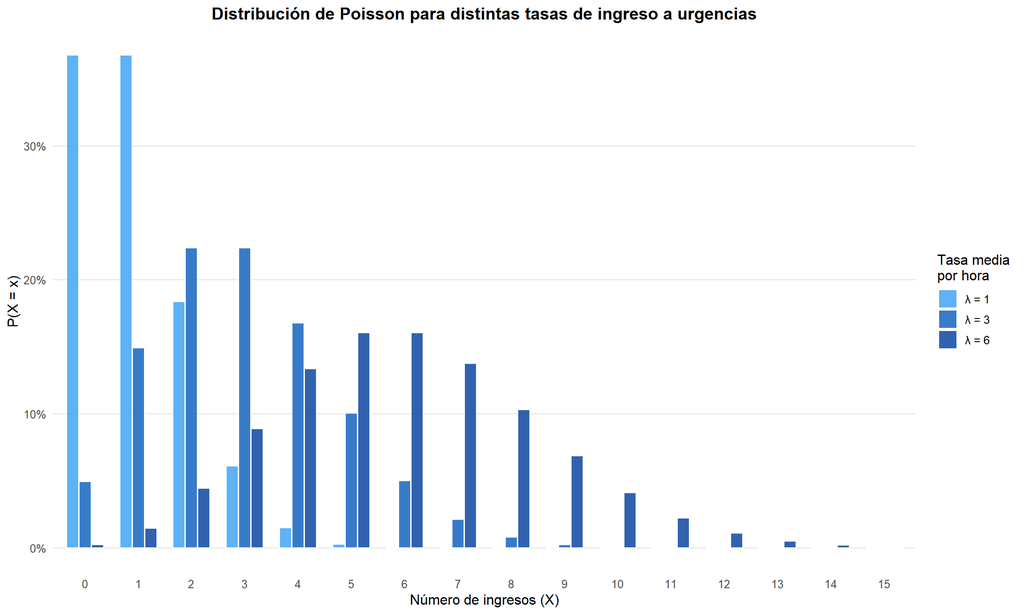

# DISTRIBUCIONES CONTINUAS

## Distribución Normal

### Definición

La distribución **Normal** (o gaussiana) es la distribución continua más importante en estadística. Una variable $X$ sigue una distribución Normal con media $\mu$ y varianza $\sigma^2$:

$$X \sim N(\mu, \sigma^2)$$

### Función de densidad

$$\boxed{f(x) = \frac{1}{\sigma\sqrt{2\pi}}\; e^{-\frac{(x-\mu)^2}{2\sigma^2}}, \quad x \in \mathbb{R}}$$

## Propiedades de la Distribución Normal

- **Simétrica** respecto a $\mu$
- **Unimodal** con moda = mediana = $\mu$
- La curva es asintótica al eje X
- $E[X] = \mu$, $Var(X) = \sigma^2$
- El parámetro $\sigma$ controla la **dispersión**

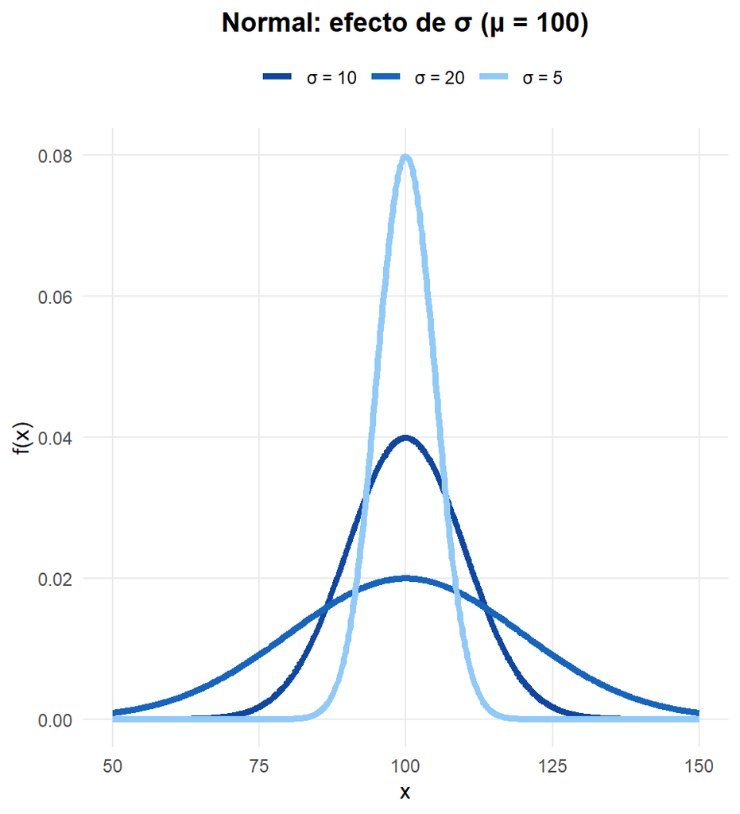

## Regla 68 — 95 — 99.7

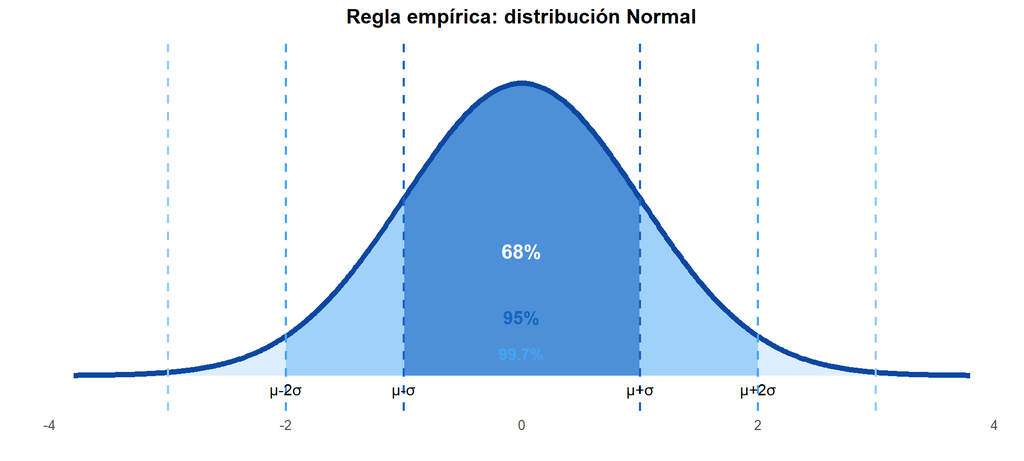

$$P(\mu - \sigma \leq X \leq \mu + \sigma) \approx 0.68 \qquad P(\mu - 2\sigma \leq X \leq \mu + 2\sigma) \approx 0.95$$

## Ejemplo: Presión Arterial Sistólica

La **presión arterial sistólica** (PAS) en adultos sanos sigue una distribución aproximadamente normal:

$$PAS \sim N(120,\; 15^2) \text{ mmHg}$$

**¿Qué proporción de adultos tiene PAS entre 105 y 135 mmHg?**

$$P(105 \leq PAS \leq 135) = P(120 - 15 \leq PAS \leq 120 + 15) \approx 0.68$$

**¿Cuál es la probabilidad de que un adulto sea hipertenso (PAS > 140)?**

$$P(PAS > 140) = 1 - P(PAS \leq 140)$$

*Usaremos `pnorm` en R para calcularlo.*

## Código R: Distribución Normal

```r
# PAS ~ N(120, 15^2) mmHg

# P(PAS < 130): paciente con PAS por debajo de 130
pnorm(q = 130, mean = 120, sd = 15)
```

```
[1] 0.7475075
```

```r
# P(PAS > 140): paciente hipertenso (PAS > 140)
1 - pnorm(q = 140, mean = 120, sd = 15)
```

```
[1] 0.09121122
```

```r
# P(105 < PAS < 135): rango normal ± 1 desv. estándar
pnorm(135, 120, 15) - pnorm(105, 120, 15)
```

```
[1] 0.6826895
```

```r
# Percentil 95 de la PAS (valor de corte)
qnorm(p = 0.95, mean = 120, sd = 15)
```

```
[1] 144.6728
```

## Distribución Normal Estándar

### Estandarización

Si $X \sim N(\mu, \sigma^2)$, la variable **estandarizada** sigue una Normal Estándar:

$$\boxed{Z = \frac{X - \mu}{\sigma} \sim N(0, 1)}$$

> La estandarización permite comparar valores de **diferentes escalas** y usar una única tabla (o función R).

### Propiedades de $Z \sim N(0,1)$

- $E[Z] = 0$, $Var(Z) = 1$
- $f(z) = \dfrac{1}{\sqrt{2\pi}} e^{-z^2/2}$
- Simétrica: $P(Z \leq -z) = P(Z \geq z) = 1 - \Phi(z)$

## Cuantiles y Percentiles

La función $\Phi(z) = P(Z \leq z)$ se implementa con `pnorm` en R.

### Valores críticos más usados

| Nivel | $z_{\alpha/2}$ |
| --- | --- |
| 90% | $z_{0.05} = 1.645$ |
| 95% | $z_{0.025} = 1.960$ |
| 99% | $z_{0.005} = 2.576$ |

### En R

```r
# Percentil 97.5
qnorm(0.975)
```

```
[1] 1.959964
```

```r
# Percentil 99.5
qnorm(0.995)
```

```
[1] 2.575829
```

```r
# P(Z < 1.96)
pnorm(1.96)
```

```
[1] 0.9750021
```

## Código R: Normal Estándar y Estandarización

```r
# P(-1.96 < Z < 1.96)
pnorm(1.96) - pnorm(-1.96)
```

```
[1] 0.9500042
```

```r
# Estandarizar: PAS = 145 mmHg (mu=120, sigma=15)
z <- (145 - 120) / 15
cat("Z =", round(z, 3))
```

```
Z = 1.667
```

```r
cat("\nP(PAS > 145) = P(Z >", round(z, 3), ") =",
    round(1 - pnorm(z), 4))
```

```
P(PAS > 145) = P(Z > 1.667 ) = 0.0478
```

```r
# Intervalo de referencia clínica al 95%
cat("\nIC 95%: [",
    round(qnorm(0.025, 120, 15), 1), ",",
    round(qnorm(0.975, 120, 15), 1), "] mmHg")
```

```
IC 95%: [ 90.6 , 149.4 ] mmHg
```

## Ejemplo completo: Glucemia en ayunas

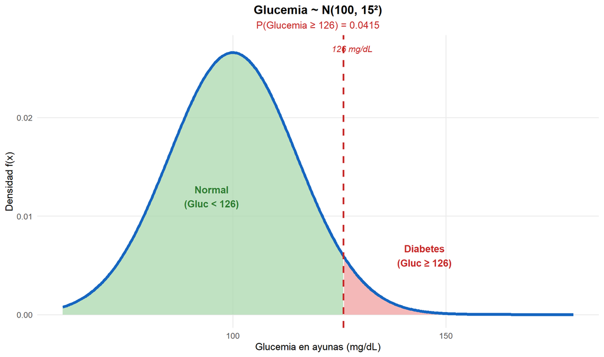

### Código R del ejemplo glucemia

```r
# Glucemia en ayunas ~ N(100, 15^2) mg/dL

# P(Glucemia >= 126): probabilidad de diagnóstico de diabetes
1 - pnorm(q = 126, mean = 100, sd = 15)
```

```
[1] 0.04151822
```

```r
# Valor de corte para prediabetes (percentil 80)
qnorm(p = 0.80, mean = 100, sd = 15)
```

```
[1] 112.6243
```

```r
# Simular 500 pacientes y contar cuántos superan 126
set.seed(2024)
glucemia <- rnorm(n = 500, mean = 100, sd = 15)
mean(glucemia >= 126)
```

```
[1] 0.038
```

# GRACIAS!

# Citación y derechos de autor

Este material ha sido creado por [Giovany Babativa-Márquez](https://github.com/jgbabativam) y es de libre distribución bajo la licencia [Creative Commons Attribution-ShareAlike 4.0](https://creativecommons.org/licenses/by-sa/4.0/).

Cualquier copia parcial o total de este material, debe citar la fuente como:

> Babativa-Márquez, J.G. *Diapositivas del curso de Estadística Fundamental para Ciencias de la Salud*. URL: https://jgbabativam.github.io/EstadFundSalud/